# mfinn13_FinalHomeworkCode_03

2025-05-03

*Loading in the data set*

```r
library(curl)
file <- curl("https://raw.githubusercontent.com/fuzzyatelin/fuzzyatelin.github.io/refs/heads/master/AN588_Spring25/zombies.csv")
zombies <- read.csv(file, header = T, sep = ",")
```

# Problem 1

Calculate the population mean and standard deviation for each quantitative random variable (height, weight, age, number of zombies killed, and years of education). NOTE: You will not want to use the built in var() and sd() commands as these are for samples.

```r
#viewing dataset so I know the variable names
View(zombies)

#function for calculating population standard deviation
pop_SD <- function(data) {
  sqrt(sum((data - mean(data))^2)/(length(data)))
}

#height
paste("The mean height is ", mean(zombies$height), sep = "")
```

```
## [1] "The mean height is 67.63009808295"
```

```r
paste("Ehe standard deviation for height is ", pop_SD(zombies$height), sep = "")
```

```
## [1] "Ehe standard deviation for height is 4.30797010678797"
```

```r
#weight
paste("The mean weight is ", mean(zombies$weight), sep = "")
```

```
## [1] "The mean weight is 143.90747819936"
```

```r
paste("Ehe standard deviation for weight is ", pop_SD(zombies$weight), sep = "")
```

```
## [1] "Ehe standard deviation for weight is 18.3918570867276"
```

```r
#age
paste("The mean age is ", mean(zombies$age), sep = "")
```

```
## [1] "The mean age is 20.04696112212"
```

```r
paste("Ehe standard deviation for age is ", pop_SD(zombies$age), sep = "")
```

```
## [1] "Ehe standard deviation for age is 2.96358265176487"
```

```r
#number of zombies killed
paste("The mean zombies killed is ", mean(zombies$zombies_killed), sep = "")
```

```
## [1] "The mean zombies killed is 2.992"
```

```r
paste("Ehe standard deviation for zombies killed is ", pop_SD(zombies$zombies_killed), sep = "")
```

```
## [1] "Ehe standard deviation for zombies killed is 1.74755142985836"
```

```r
#years of education
paste("The mean years of education is ", mean(zombies$years_of_education), sep = "")
```

```
## [1] "The mean years of education is 2.996"
```

```r
paste("Ehe standard deviation for years of education is ", pop_SD(zombies$years_of_education), sep = "")
```

```
## [1] "Ehe standard deviation for years of education is 1.67570403114631"
```

# Problem 2

Use {ggplot} to make boxplots of each of these variables by gender.

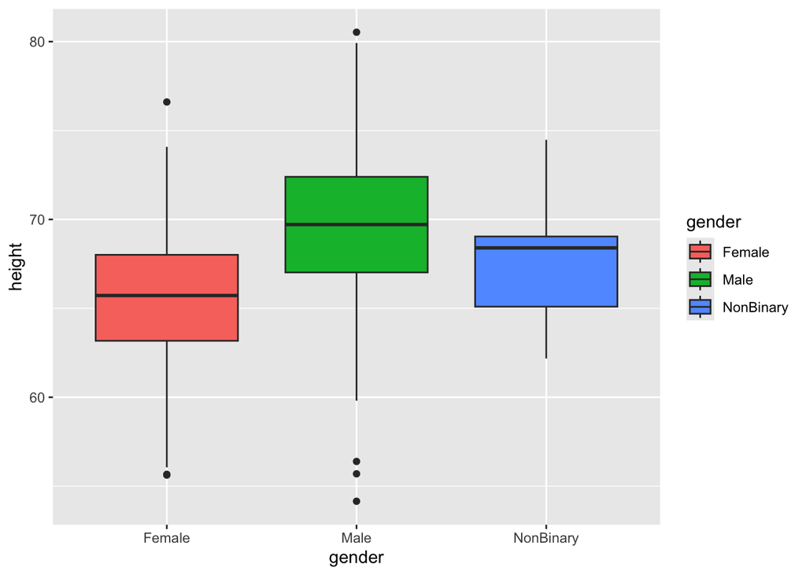

```r
library(ggplot2)

#height
heightVgender_Box <- ggplot(data = zombies, aes(x = gender, y = height, fill = gender)) + geom_boxplot()
print(heightVgender_Box)
```

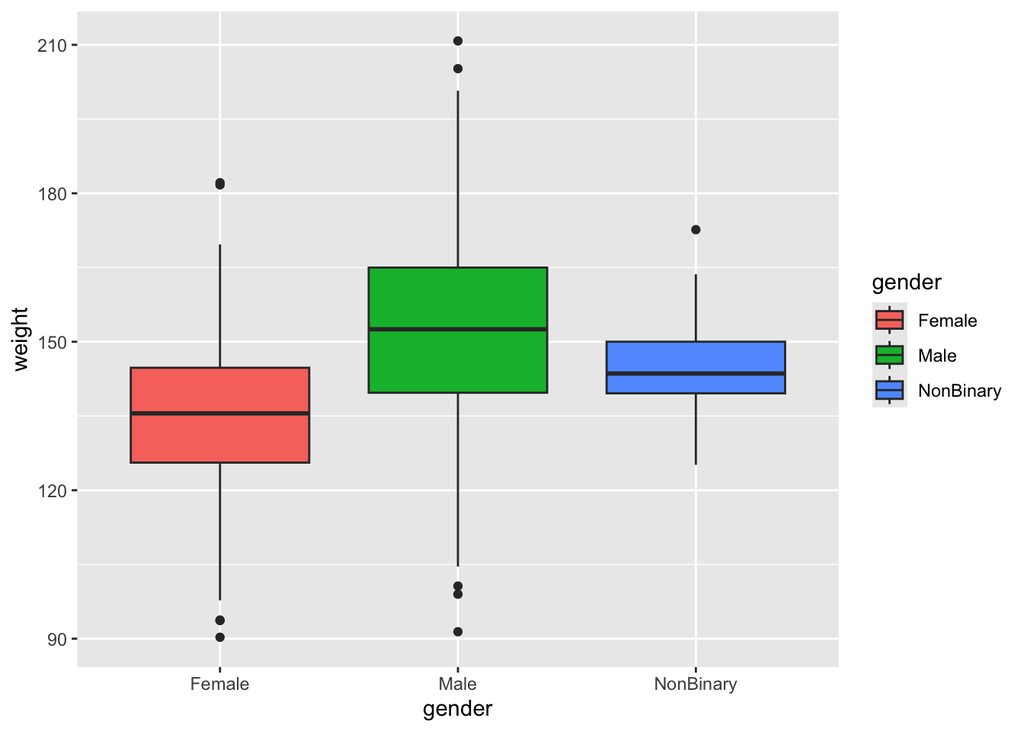

```r
#weight
weightVgender_Box <- ggplot(data = zombies, aes(x = gender, y = weight, fill = gender)) + geom_boxplot()
print(weightVgender_Box)
```

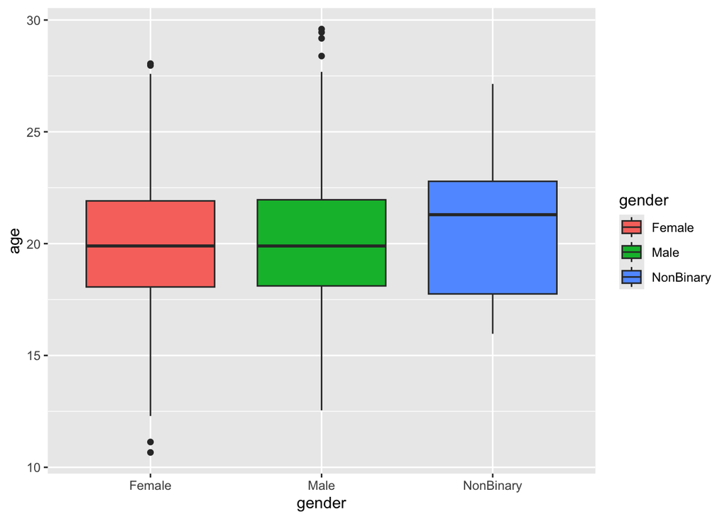

```r
#age
ageVgender_Box <- ggplot(data = zombies, aes(x = gender, y = age, fill = gender)) + geom_boxplot()
print(ageVgender_Box)
```

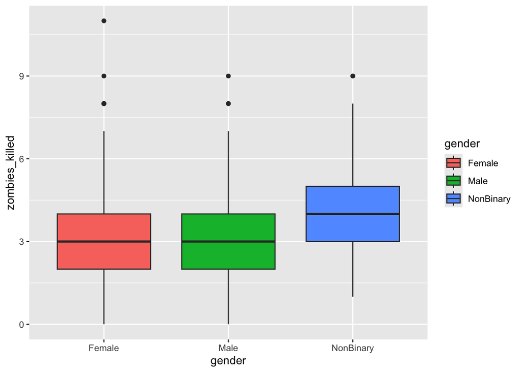

```r
#number of zombies killed
killsVgender_Box <- ggplot(data = zombies, aes(x = gender, y = zombies_killed, fill = gender)) + geom_boxplot()
print(killsVgender_Box)
```

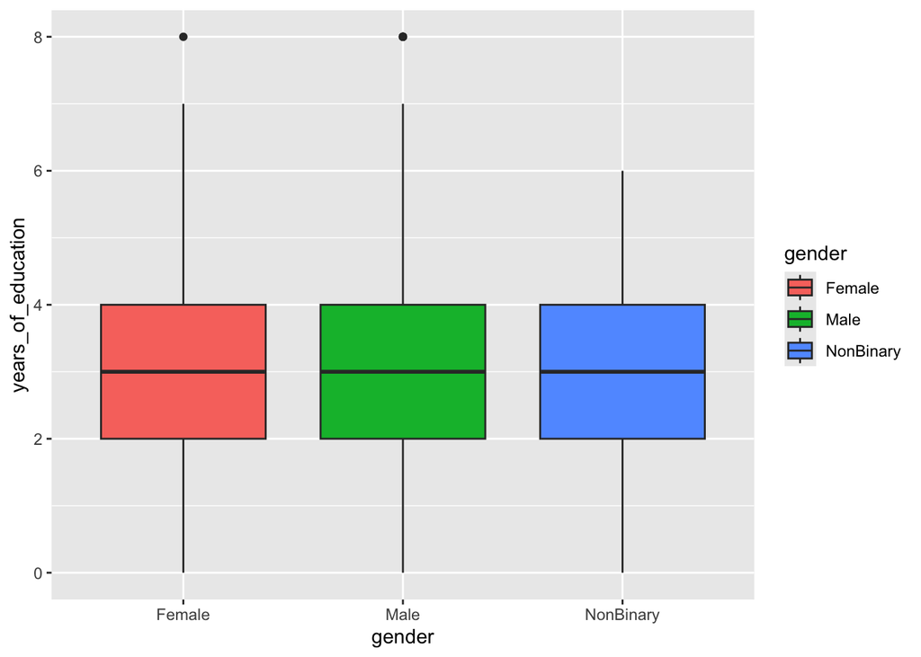

```r
#years of education
educationVgender_Box <- ggplot(data = zombies, aes(x = gender, y = years_of_education, fill = gender)) + geom_boxplot()
print(educationVgender_Box)
```

# Problem 3

Use {ggplot} to make scatter plots of height and weight in relation to age. Do these variables seem to be related? In what way?

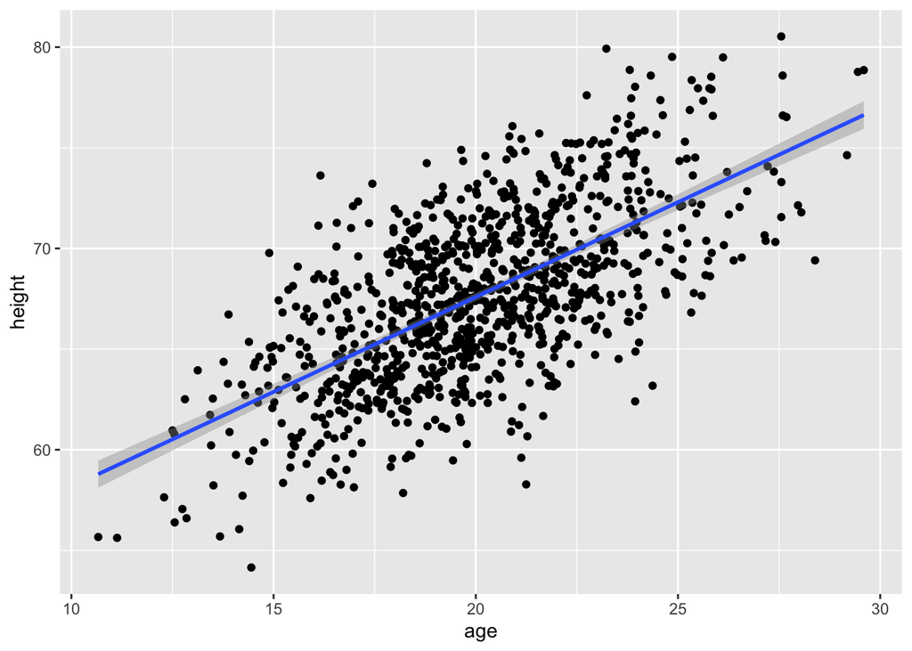

```r
#height and age relation scatterplot
heightAge_scatter <- ggplot(data = zombies, aes(x = age, y = height)) + geom_point() + geom_smooth(method = "lm")
heightAge_scatter
```

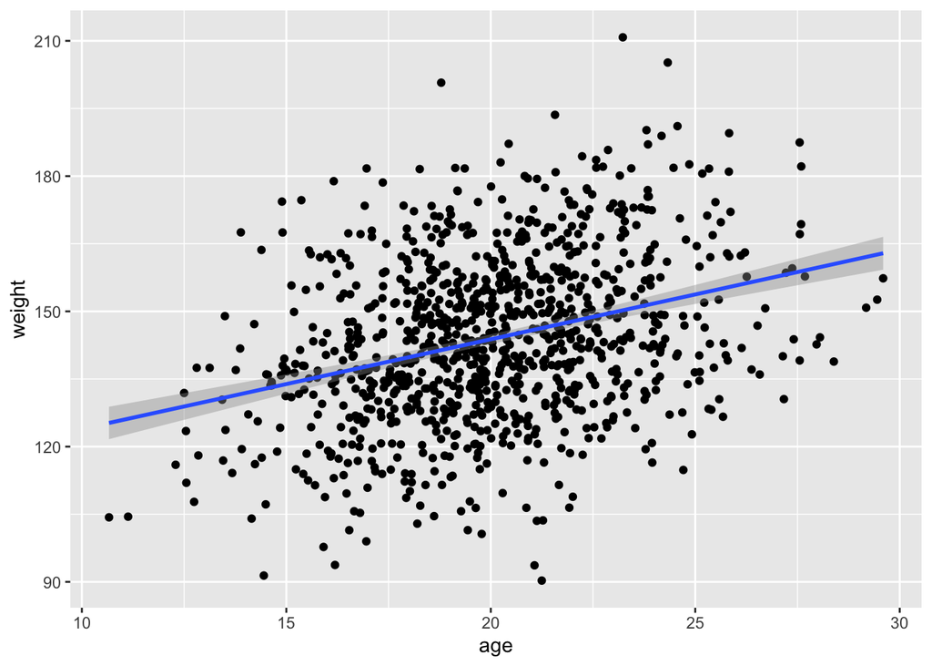

```r
#weight and age relation scatterplot
weightAge_scatter <- ggplot(data = zombies, aes(x = age, y = weight)) + geom_point() + geom_smooth(method = "lm")
weightAge_scatter
```

```r
print("Both height and weight seem to be positively correlated with age, though height seems to have a stronger correlation.")
```

```
## [1] "Both height and weight seem to be positively correlated with age, though height seems to have a stronger correlation."
```

# Problem 4

Using histograms and Q-Q plots, check whether the quantitative variables seem to be drawn from a normal distribution. Which seem to be and which do not (hint: not all are drawn from the normal distribution)? For those that are not normal, can you determine from which common distribution they are drawn?

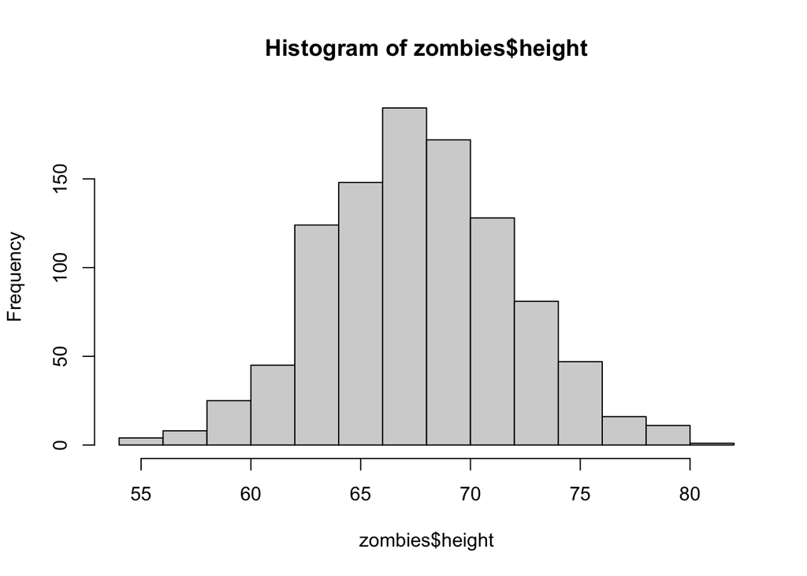

```r
#height
hist(zombies$height)
```

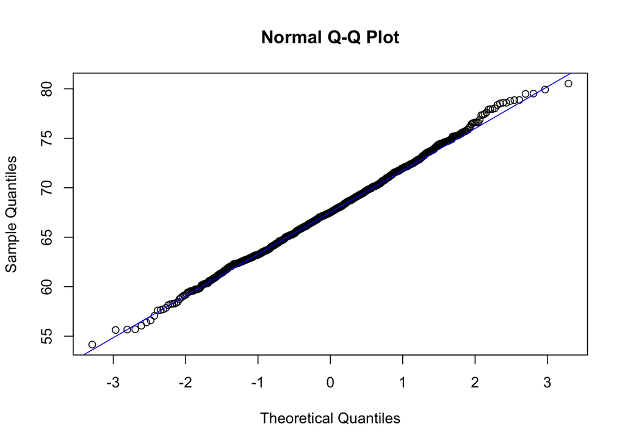

```r
qqnorm(zombies$height)
qqline(zombies$height, col = "blue")
```

```r
print("Based on the histogram and the Q-Q plot, height seems to be normally distributed.")
```

```
## [1] "Based on the histogram and the Q-Q plot, height seems to be normally distributed."
```

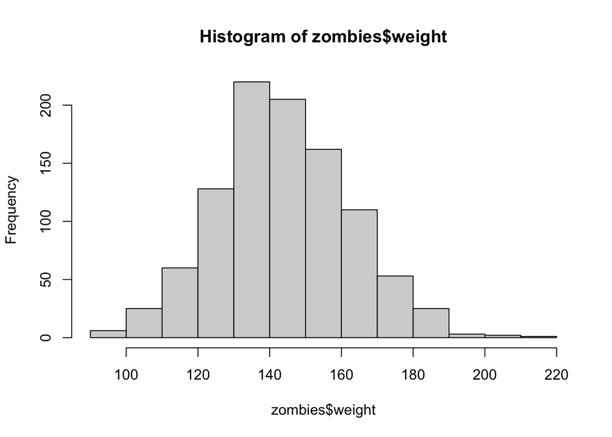

```r
#weight
hist(zombies$weight)
```

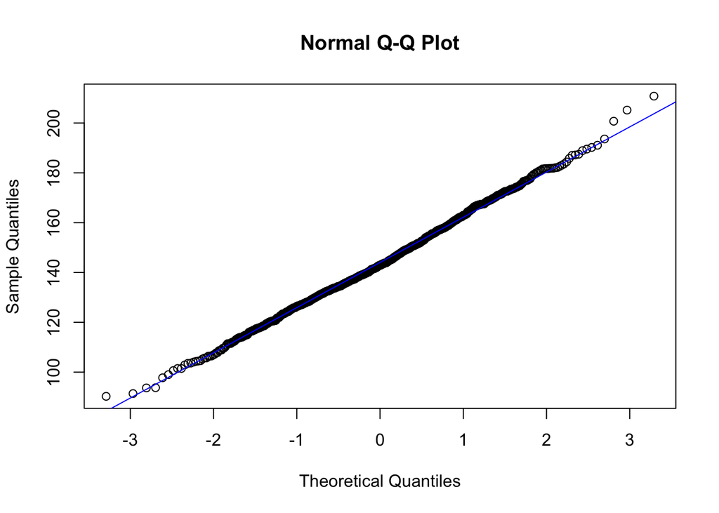

```r
qqnorm(zombies$weight)
qqline(zombies$weight, col = "blue")
```

```r
print("Based on the histogram and the Q-Q plot, weight seems to be normally distributed.")
```

```
## [1] "Based on the histogram and the Q-Q plot, weight seems to be normally distributed."
```

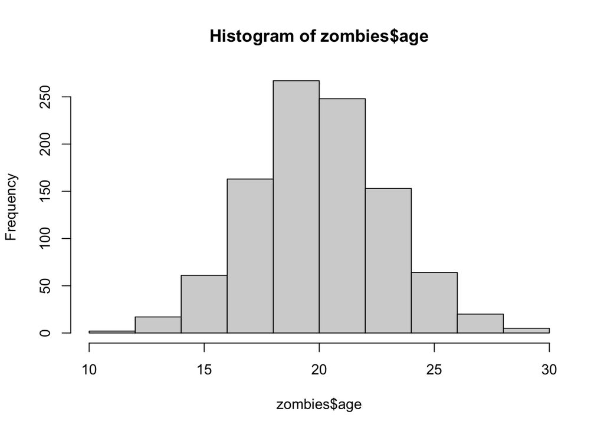

```r
#age
hist(zombies$age)
```

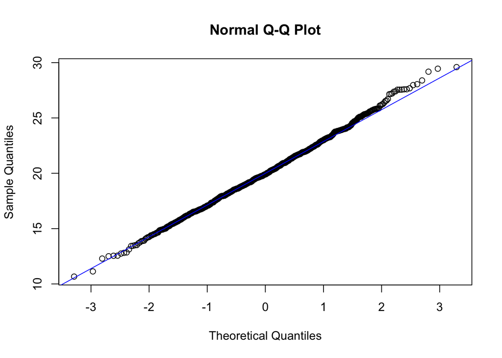

```r
qqnorm(zombies$age)
qqline(zombies$age, col = "blue")
```

```r
print("Based on the histogram and the Q-Q plot, age seems to be normally distributed.")
```

```
## [1] "Based on the histogram and the Q-Q plot, age seems to be normally distributed."
```

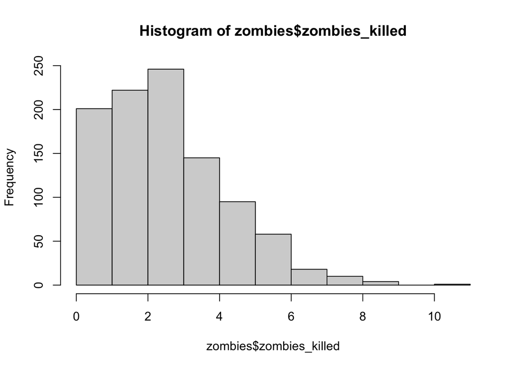

```r
#zombie kills
hist(zombies$zombies_killed)
```

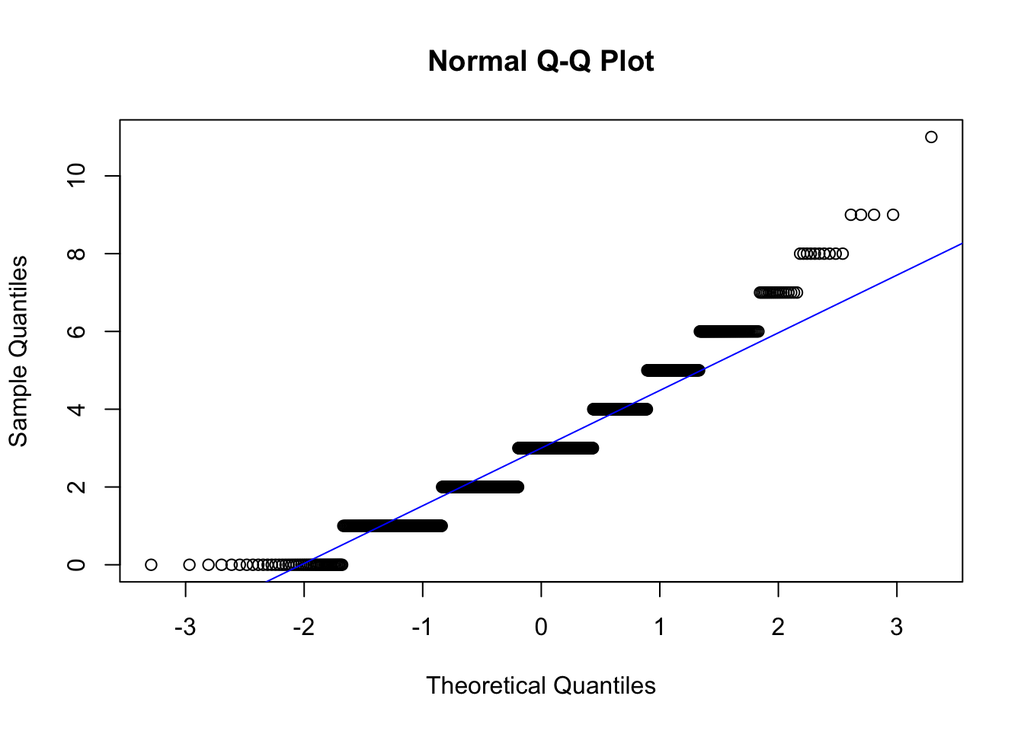

```r
qqnorm(zombies$zombies_killed)
qqline(zombies$zombies_killed, col = "blue")
```

```r
print("The histogram is heavily right-skewed, and the Q-Q plot does not fall on the line. Zombies killed is not normally distributed. Because the number of kills is count data which could take on a value between 0 and infinity, this is likely from a poisson distribution.")
```

```
## [1] "The histogram is heavily right-skewed, and the Q-Q plot does not fall on the line. Zombies killed is not normally distributed. Because the number of kills is count data which could take on a value between 0 and infinity, this is likely from a poisson distribution."
```

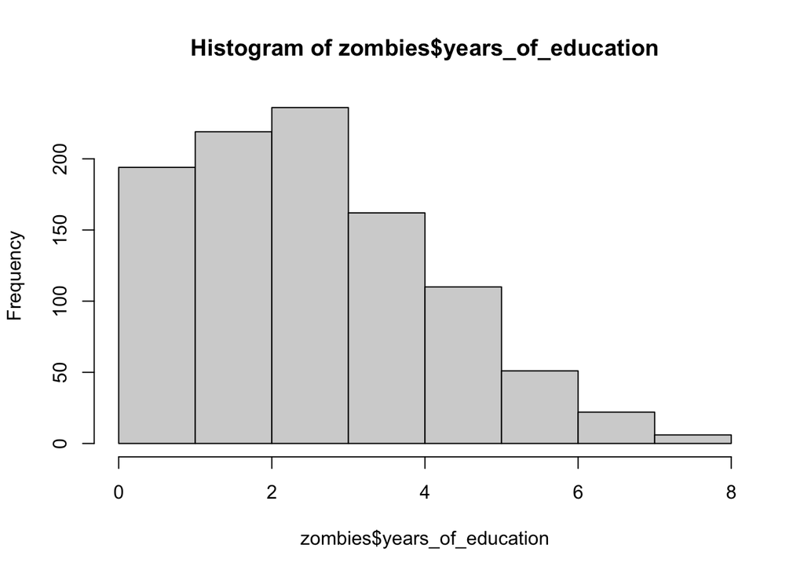

```r
#years of education
hist(zombies$years_of_education)
```

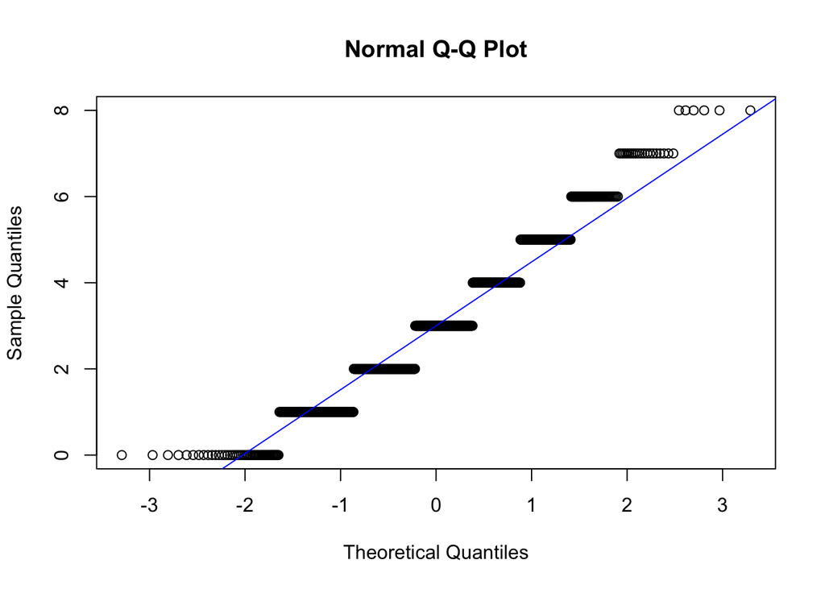

```r
qqnorm(zombies$years_of_education)
qqline(zombies$years_of_education, col = "blue")
```

```r
print("The histogram is right-skewed, and the Q-Q plot does not fall on the line. Years of education is not normally distributed. Because the number of kills is count data which could take on a value between 0 and infinity, this is likely also from a poisson distribution.")
```

```
## [1] "The histogram is right-skewed, and the Q-Q plot does not fall on the line. Years of education is not normally distributed. Because the number of kills is count data which could take on a value between 0 and infinity, this is likely also from a poisson distribution."
```

# Problem 5

Now use the sample() function to sample ONE subset of 30 zombie survivors (without replacement) from this population and calculate the mean and sample standard deviation for each variable. Also estimate the standard error for each variable, and construct the 95% confidence interval for each mean. Note that for the variables that are not drawn from the normal distribution, you may need to base your estimate of the CIs on slightly different code than for the normal…

```r
#First, create a subset of 30 random survivors
set.seed(1) #so it doesn't change every time
randomSurvivors_30 <- zombies[sample(nrow(zombies), 30), ] #selects 30 random rows out of the dataset, and chooses those rows (which are each survivors with all of their data)
randomSurvivors_30
```

```
##      id  first_name last_name gender   height   weight zombies_killed
## 836 836       Susan   Hawkins Female 69.35963 133.1018              3
## 679 679    Benjamin      Ward   Male 61.95252 139.9611              2
## 129 129      Martin    Wagner   Male 70.26668 154.6746              2
## 930 930       Keith    Wagner   Male 63.24096 132.8480              3
## 509 509       Doris      Lane Female 62.33275 134.0491              3
## 471 471    Jennifer  Williams Female 62.29205 144.9394              2
## 299 299       Kelly     Burke Female 69.91124 145.7389              5
## 270 270 Christopher       Lee   Male 67.64806 130.5163              2
## 978 978      Willie  Richards   Male 64.73728 133.3641              5
## 187 187         Ann      Reid Female 71.02192 141.7984              2
## 307 307        Judy    Peters Female 63.76315 127.8650              4
## 597 597       Linda Patterson Female 63.14829 106.4643              2
## 277 277      Carlos Alexander   Male 75.21887 176.9457              3
## 874 874        Sean    Brooks   Male 68.52690 126.8207              1
```

[output cut: 47 more lines]

```r
#HEIGHT (normal)
rs30_mean_height <- mean(randomSurvivors_30$height) #calculates mean height
rs30_sd_height <- sd(randomSurvivors_30$height) #calculates standard deviation (we can use sd() because this is a sample)
rs30_se_height <- rs30_sd_height/sqrt(30) #calculates standard error
qnorm(0.975) #the critical value for a normal distribution (which is symmetrical) when alpha is 0.05 (95% confidence) and the sample is greater than or equal to 30
```

```
## [1] 1.959964
```

```r
rs30_CIupper_height <- rs30_mean_height + (rs30_se_height*qnorm(0.975)) #calculates CI upper limit
rs30_CIlower_height <- rs30_mean_height - (rs30_se_height*qnorm(0.975)) #calculates CI lower limit
cat("The mean height is",rs30_mean_height,". The standard deviation for height is",rs30_sd_height, ".The standard error for height is",rs30_se_height, ".The 95% confidence interval for the mean of the height is (",rs30_CIlower_height,",", rs30_CIupper_height,").")
```

```
## The mean height is 66.88522 . The standard deviation for height is 3.735037 .The standard error for height is 0.6819214 .The 95% confidence interval for the mean of the height is ( 65.54868 , 68.22176 ).
```

```r
#WEIGHT (normal)
rs30_mean_weight <- mean(randomSurvivors_30$weight)
rs30_sd_weight <- sd(randomSurvivors_30$weight) #calculates standard deviation (we can use sd() because this is a sample)
rs30_se_weight <- rs30_sd_weight/sqrt(30) #calculates standard error
qnorm(0.975) #thethe critical value for a normal distribution (which is symmetrical) when alpha is 0.05 (95% confidence) and the sample is greater than or equal to 30
```

```
## [1] 1.959964
```

```r
rs30_CIupper_weight <- rs30_mean_weight + (rs30_se_weight*qnorm(0.975)) #calculates CI upper limit
rs30_CIlower_weight <- rs30_mean_weight - (rs30_se_weight*qnorm(0.975)) #calculates CI lower limit
cat("The mean weight is",rs30_mean_weight,". The standard deviation for weight is",rs30_sd_height, ".The standard error for weight is",rs30_se_weight, ".The 95% confidence interval for the mean of the weight is (",rs30_CIlower_weight,",", rs30_CIupper_weight,").")
```

[output not shown]

```r
#AGE (normal)
rs30_mean_age <- mean(randomSurvivors_30$age)
rs30_sd_age <- sd(randomSurvivors_30$age) #calculates standard deviation (we can use sd() because this is a sample)
rs30_se_age <- rs30_sd_age/sqrt(30) #calculates standard error
qnorm(0.975) #the critical value for a normal distribution (which is symmetrical) when alpha is 0.05 (95% confidence) and the sample is greater than or equal to 30.
```

```
## [1] 1.959964
```

```r
rs30_CIupper_age <- rs30_mean_age + (rs30_se_age*qnorm(0.975)) #calculates CI upper limit
rs30_CIlower_age <- rs30_mean_age - (rs30_se_age*qnorm(0.975)) #calculates CI lower limit
cat("The mean age is",rs30_mean_age,". The standard deviation for age is",rs30_sd_age, ".The standard error for age is",rs30_se_age, ".The 95% confidence interval for the mean of the age is (",rs30_CIlower_age,",", rs30_CIupper_age,").")
```

```
## The mean age is 19.68657 . The standard deviation for age is 2.960476 .The standard error for age is 0.5405065 .The 95% confidence interval for the mean of the age is ( 18.62719 , 20.74594 ).
```

```r
#ZOMBIE KILLS (non-normal)
rs30_mean_zombies_killed <- mean(randomSurvivors_30$zombies_killed)
rs30_sd_zombies_killed <- sd(randomSurvivors_30$zombies_killed) #calculates standard deviation (we can use sd() because this is a sample)
rs30_se_zombies_killed <- rs30_sd_zombies_killed/sqrt(30) #calculates standard error
#because this is not normally distributed, we have to use bootstrapping to estimate a confidence interval
setOfMeans_kills <- NULL #sets null object which we will full with simulated means
for (i in 1:10000){
  setOfMeans_kills[i] <- mean(sample(zombies$zombies_killed, 30, replace = F)) #creates a dataset of 10000 means, each calculated from a random sample of size 30 from our zombies dataset
}
rs30_CIlower_kills <- quantile(setOfMeans_kills, 0.025) #tells us the value in the set of means which 2.5% of values are lower (this is our lower bound)
rs30_CIupper_kills <- quantile(setOfMeans_kills, 0.975) #tell us the value in the set of means which 97.5% of values are lower (this is our upper bound)
cat("The mean number of kills is",rs30_mean_zombies_killed,". The standard deviation for number of kills is",rs30_sd_zombies_killed, ".The standard error for kills is",rs30_se_zombies_killed, ".The 95% confidence interval for the mean of the number of kills is (",rs30_CIlower_kills,",", rs30_CIupper_kills,").")
```

```
## The mean number of kills is 3.066667 . The standard deviation for number of kills is 1.680175 .The standard error for kills is 0.3067566 .The 95% confidence interval for the mean of the number of kills is ( 2.4 , 3.633333 ).
```

```r
#YEARS OF EDUCATION (non-normal)
rs30_mean_years_of_education <- mean(randomSurvivors_30$years_of_education)
rs30_sd_years_of_education <- sd(randomSurvivors_30$years_of_education) #calculates standard deviation (we can use sd() because this is a sample)
rs30_se_years_of_education <- rs30_sd_years_of_education/sqrt(30) #calculates standard error
#because this is not normally distributed, we have to use bootstrapping to estimate a confidence interval
setOfMeans_education <- NULL #sets null object which we will full with simulated means
for (i in 1:10000){
  setOfMeans_education[i] <- mean(sample(zombies$years_of_education, 30, replace = F)) #creates a dataset of 10000 means, each calculated from a random sample of size 30 from our zombies dataset
}
rs30_CIlower_education <- quantile(setOfMeans_education, 0.025) #tells us the value in the set of means which 2.5% of values are lower (this is our lower bound)
rs30_CIupper_education <- quantile(setOfMeans_education, 0.975) #tell us the value in the set of means which 97.5% of values are lower (this is our upper bound)
cat("The mean years of education is",rs30_mean_years_of_education,". The standard deviation for years of education is",rs30_sd_years_of_education, ".The standard error for years of education is",rs30_se_years_of_education, ".The 95% confidence interval for the mean of years of education is (",rs30_CIlower_education,",", rs30_CIupper_education,").")
```

```
## The mean years of education is 2.966667 . The standard deviation for years of education is 1.691425 .The standard error for years of education is 0.3088106 .The 95% confidence interval for the mean of years of education is ( 2.433333 , 3.6 ).
```

# Problem 6

Now draw 99 more random samples of 30 zombie apocalypse survivors, and calculate the mean for each variable for each of these samples. Together with the first sample you drew, you now have a set of 100 means for each variable (each based on 30 observations), which constitutes a sampling distribution for each variable. What are the means and standard deviations of this distribution of means for each variable? How do the standard deviations of means compare to the standard errors estimated in [5]? What do these sampling distributions look like (a graph might help here)? Are they normally distributed? What about for those variables that you concluded were not originally drawn from a normal distribution?

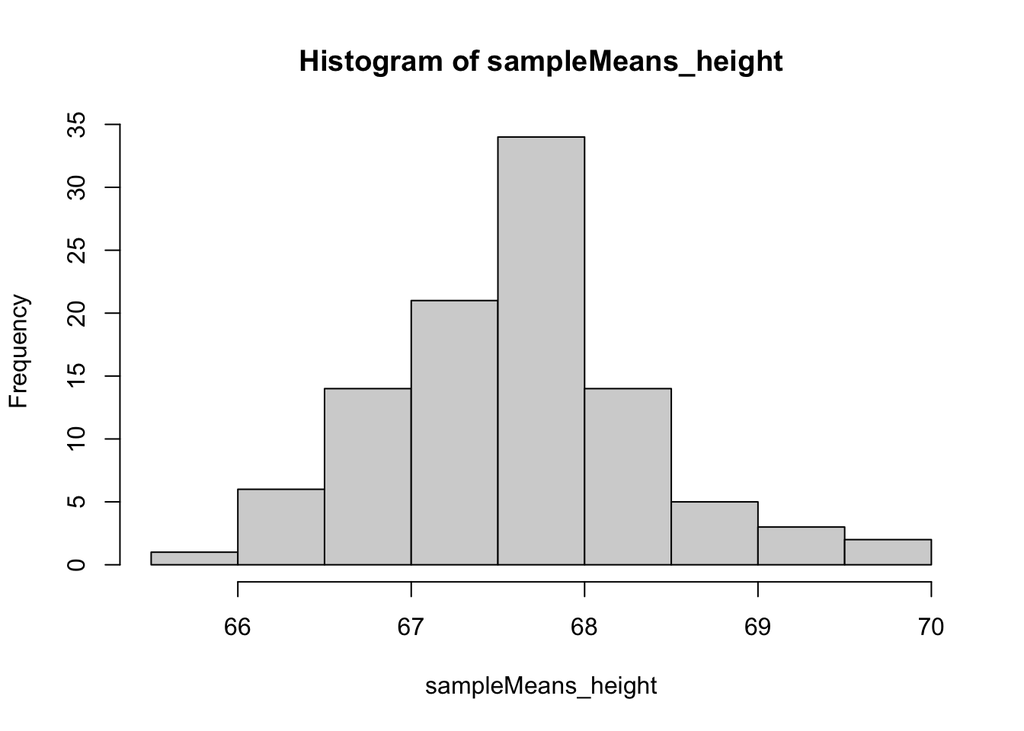

```r
#HEIGHT
sampleMeans_height <- NULL #creating dataset which will be filled
for (i in 1:100){
  sampleMeans_height[i] <- mean(sample(zombies$height, 30, replace = F)) #this for loop fills up sampleMeans_height with 100 mean heights calculated from samples of size 30 from the zombies dataset.
}
mean_sampleMeans_height <- mean(sampleMeans_height) #calculates mean
sd_sampleMeans_height <- sd(sampleMeans_height) #calculates sd
hist(sampleMeans_height) #histogram for assessing normality visually
```

```r
cat("The mean for the distribution of means of height is", mean_sampleMeans_height, ". The sd for the distribution of means of height is", sd_sampleMeans_height,". while the SE from part 5 was",rs30_se_height, ". The distribution of means for height is normally distributed.")
```

```
## The mean for the distribution of means of height is 67.59756 . The sd for the distribution of means of height is 0.743753 . while the SE from part 5 was 0.6819214 . The distribution of means for height is normally distributed.
```

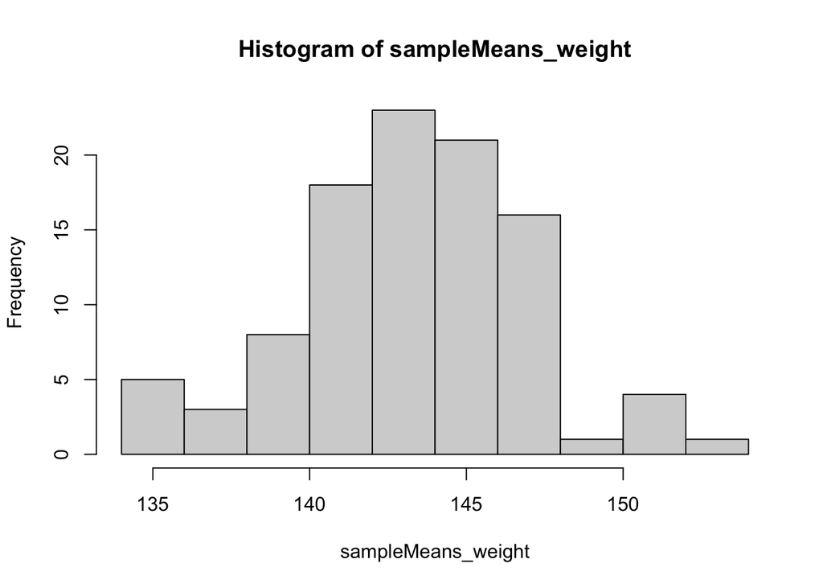

```r
#WEIGHT
sampleMeans_weight <- NULL #creating dataset which will be filled
for (i in 1:100){
  sampleMeans_weight[i] <- mean(sample(zombies$weight, 30, replace = F)) #this for loop fills up sampleMeans_height with 100 mean heights calculated from samples of size 30 from the zombies dataset.
}
mean_sampleMeans_weight <- mean(sampleMeans_weight) #calculates mean
sd_sampleMeans_weight <- sd(sampleMeans_weight) #calculates sd
hist(sampleMeans_weight) #histogram for assessing normality visually
```

```r
cat("The mean for the distribution of means of weight is", mean_sampleMeans_weight, ". The sd for the distribution of means of weight is", sd_sampleMeans_weight,". while the SE from part 5 was",rs30_se_weight, ". The distribution of means for weight is approximately normally distributed.")
```

```
## The mean for the distribution of means of weight is 143.3002 . The sd for the distribution of means of weight is 3.686258 . while the SE from part 5 was 2.962555 . The distribution of means for weight is approximately normally distributed.
```

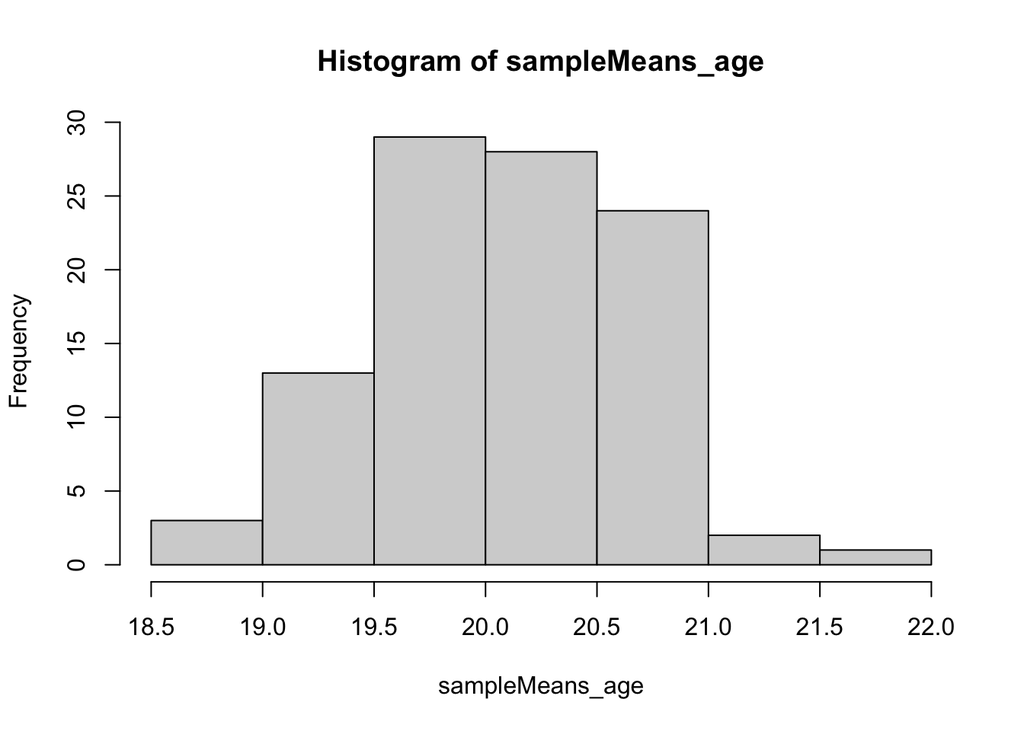

```r
#AGE
sampleMeans_age <- NULL #creating dataset which will be filled
for (i in 1:100){
  sampleMeans_age[i] <- mean(sample(zombies$age, 30, replace = F)) #this for loop fills up sampleMeans_height with 100 mean heights calculated from samples of size 30 from the zombies dataset.
}
mean_sampleMeans_age <- mean(sampleMeans_age) #calculates mean
sd_sampleMeans_age <- sd(sampleMeans_age) #calculates sd
hist(sampleMeans_age) #histogram for assessing normality visually
```

```r
cat("The mean for the distribution of means of age is", mean_sampleMeans_age, ". The sd for the distribution of means of age is", sd_sampleMeans_age,". while the SE from part 5 was",rs30_se_age, ". The distribution of means for age is approximately normally distributed.")
```

```
## The mean for the distribution of means of age is 20.08473 . The sd for the distribution of means of age is 0.5791854 . while the SE from part 5 was 0.5405065 . The distribution of means for age is approximately normally distributed.
```

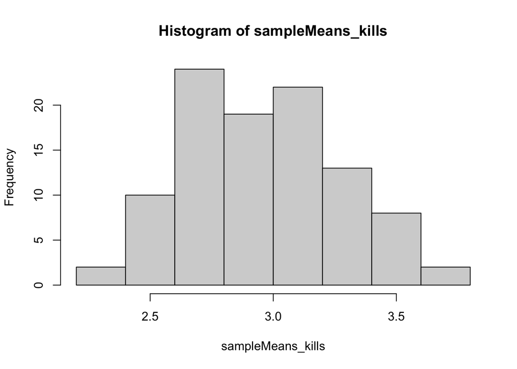

```r
#ZOMBIE KILLS
sampleMeans_kills <- NULL #creating dataset which will be filled
for (i in 1:100){
  sampleMeans_kills[i] <- mean(sample(zombies$zombies_killed, 30, replace = F)) #this for loop fills up sampleMeans_height with 100 mean heights calculated from samples of size 30 from the zombies dataset.
}
mean_sampleMeans_kills <- mean(sampleMeans_kills) #calculates mean
sd_sampleMeans_kills <- sd(sampleMeans_kills) #calculates sd
hist(sampleMeans_kills) #histogram for assessing normality visually
```

```r
cat("The mean for the distribution of means of zombie kills is", mean_sampleMeans_kills, ". The sd for the distribution of means of zombie kills is", sd_sampleMeans_kills,". while the SE from part 5 was",rs30_se_zombies_killed, ". The distribution of means for zombies killed is approximately normally distributed, even though the original distribution was not normally distributed, demonstrating the central limit theorem.")
```

[output not shown]

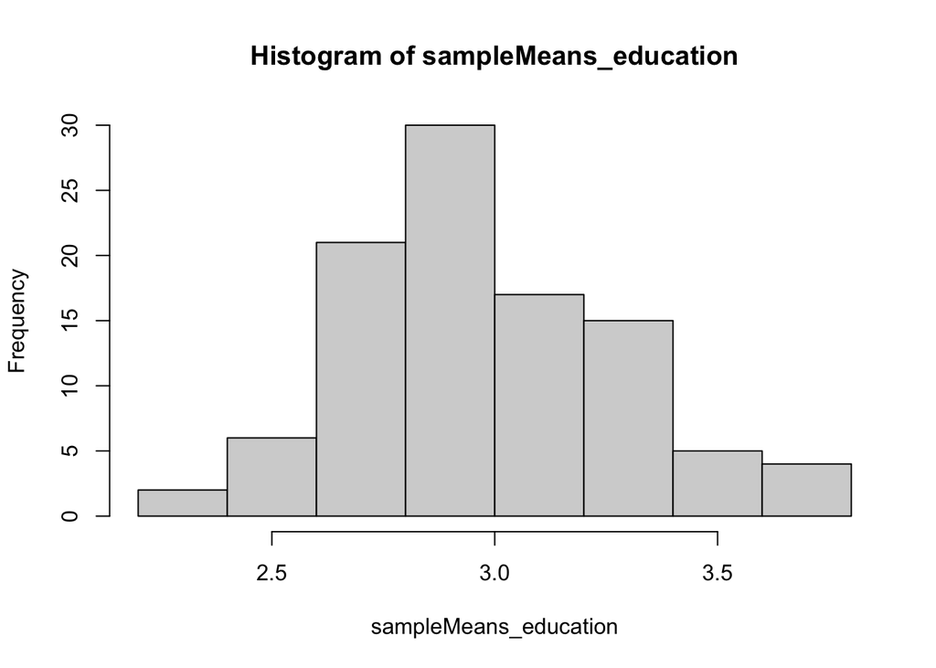

```r
#YEARS OF EDUCATION
sampleMeans_education <- NULL #creating dataset which will be filled
for (i in 1:100){
  sampleMeans_education[i] <- mean(sample(zombies$years_of_education, 30, replace = F)) #this for loop fills up sampleMeans_height with 100 mean heights calculated from samples of size 30 from the zombies dataset.
}
mean_sampleMeans_education <- mean(sampleMeans_education) #calculates mean
sd_sampleMeans_education <- sd(sampleMeans_education) #calculates sd
hist(sampleMeans_education) #histogram for assessing normality visually
```

```r
cat("The mean for the distribution of means of years of education is", mean_sampleMeans_education, ". The sd for the distribution of means of years of education is", sd_sampleMeans_education,". while the SE from part 5 was",rs30_se_years_of_education, ". The distribution of means for years of education is approximately normally distributed, even though the original distribution was not normally distributed, demonstrating the central limit theorem.")
```

[output not shown]

# Challenges

1. In problem 5, I initially had trouble getting the sample function to work how I wanted it to. It kept saying that I was trying to take a sample larger than the dataset which didn’t make sense. Eventually I figured it out with some online help.
2. Throughout the homework, I wanted to print out my answers to the questions after doing all the code to solve the problems, but I was having trouble concatenating strings and numerics and kept getting errors until I found the cat() function.
3. This is not exactly a challenge, but I don’t fully understand why the module uses replacement when bootstrapping.
4. I’m still getting the hang of using for loops. I understand them conceptually but actually writing them can be a bit challenging.
5. I’m not sure of the best way of figuring what distribution a dataset fits. For problem 4, for example, knowing that zombie kills was not normal and is data that is counted made me think it was poisson, but I was not so sure for years of education.

# Alexandra Comments

I also had a hard time with the sample function. I think we used replacement when bootstrapping to make sure that we do not end up doing a permutation, which is what I believe happens when we bootstrap without replacement. Besides what you mentioned in your fifth bullet point, you could maybe use a plot from ggplot or a histogram to physically see the distribution, so you can see what visualization fits best and match the distribution to the dataset. Honestly, I just used trial and error to do mine.